# Gugus Data Kelompok Pertemuan 1 MPDW USD

2026-08-25

# Input Data

```r
library(readr)

data_USD <- read_csv("C:\\Users\\Aquila\\Downloads\\usd_idr_daily_cleaned.csv")
data_USD
```

```
## # A tibble: 6,351 × 5
##    Date                 Open  High   Low Close
##    <dttm>              <dbl> <dbl> <dbl> <dbl>
##  1 2001-06-27 23:00:00 11441 11565 11338 11448
##  2 2001-06-28 23:00:00 11370 11510 11265 11390
##  3 2001-07-01 23:00:00 11315 11490 11215 11320
##  4 2001-07-02 23:00:00 11330 11455 11188 11322
##  5 2001-07-03 23:00:00 11355 11465 11251 11365
##  6 2001-07-04 23:00:00 11357 11485 11240 11357
##  7 2001-07-05 23:00:00 11340 11440 11230 11330
##  8 2001-07-08 23:00:00 11330 11433 11223 11330
##  9 2001-07-09 23:00:00 11370 11470 11252 11352
## 10 2001-07-10 23:00:00 11354 11458 11240 11340
## # ℹ 6,341 more rows
```

Dataset merupakan data time series harian yang mencatat pergerakan nilai tukar USD terhadap IDR. Setiap baris menunjukkan kondisi nilai tukar pada satu hari perdagangan, sedangkan setiap kolom berisi informasi mengenai pergerakan nilai tukar pada hari tersebut.

Kolom Date menunjukkan tanggal pengamatan. Kolom Open menunjukkan nilai tukar pada awal perdagangan Kolom High menunjukkan nilai tukar tertinggi Kolom Low menunjukkan nilai tukar terendah Kolom Close menunjukkan nilai tukar pada akhir perdagangan.

# Filter Data into 2024 and Close only

```r
library(dplyr)
library(stringr)

USD_2024 <- data_USD %>%
  filter(str_starts(Date, "2024"))%>%
  select(Date, Close)
```

```r
USD_2024
```

```
## # A tibble: 262 × 2
##    Date                 Close
##    <dttm>               <dbl>
##  1 2024-01-01 00:00:00 15383.
##  2 2024-01-02 00:00:00 15383
##  3 2024-01-03 00:00:00 15498
##  4 2024-01-04 00:00:00 15555
##  5 2024-01-05 00:00:00 15511
##  6 2024-01-08 00:00:00 15478.
##  7 2024-01-09 00:00:00 15496.
##  8 2024-01-10 00:00:00 15534.
##  9 2024-01-11 00:00:00 15555
## 10 2024-01-12 00:00:00 15556.
## # ℹ 252 more rows
```

# Library + Data Exploration

```r
library("forecast")
library("graphics")
library("TTR")
library("TSA")
library("rio")
USD_2024.ts <-ts(USD_2024$Close)
```

```r
View(USD_2024)
str(USD_2024)
```

```
## tibble [262 × 2] (S3: tbl_df/tbl/data.frame)
##  $ Date : POSIXct[1:262], format: "2024-01-01 00:00:00" "2024-01-02 00:00:00" ...
##  $ Close: num [1:262] 15383 15383 15498 15555 15511 ...
```

```r
dim(USD_2024)
```

```
## [1] 262   2
```

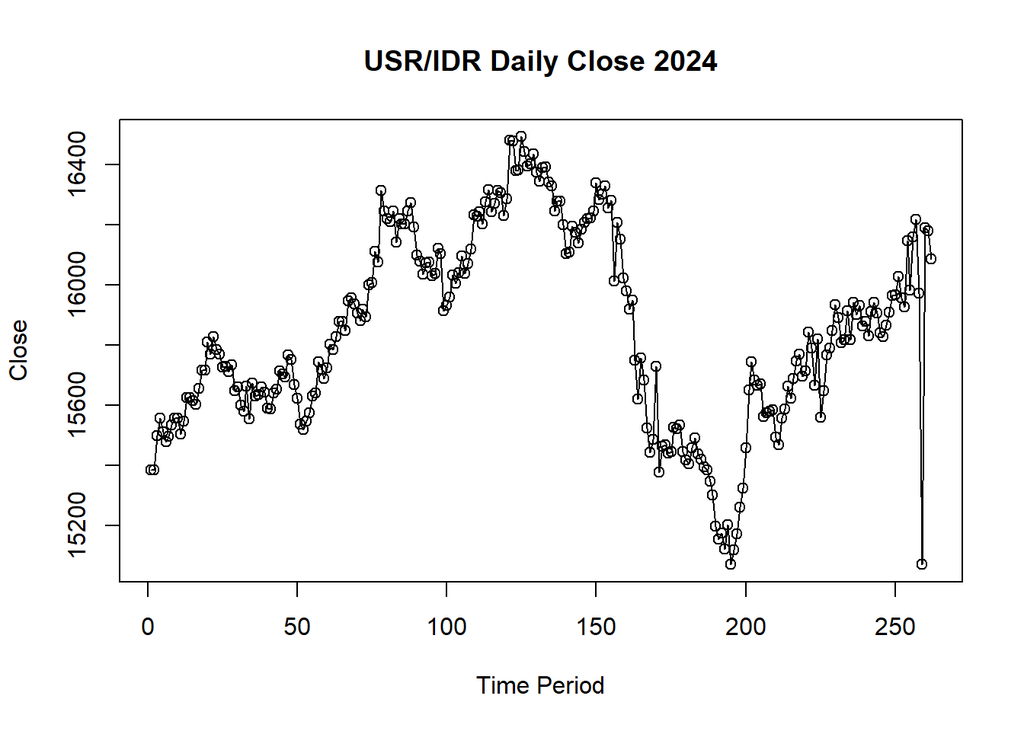

```r
ts.plot(USD_2024.ts, xlab="Time Period", ylab="Close",
        main = "USR/IDR Daily Close 2024")
points(USD_2024.ts)
```

# Single Moving Average & Double Moving Average

## Pembagian Data

Pembagian data latih dan data uji dilakukan dengan perbandingan 80% data latih dan 20% data uji.

```r
n <- nrow(USD_2024)

n_train <- floor(0.8 * n)

# bagi data
training_ma <- USD_2024[1:n_train, ]
testing_ma  <- USD_2024[(n_train+1):n, ]

# ubah ke time series
train_ma.ts <- ts(training_ma$Close)
test_ma.ts  <- ts(testing_ma$Close)
```

Eksplorasi data dilakukan pada keseluruhan data, data latih serta data uji menggunakan plot data deret waktu.

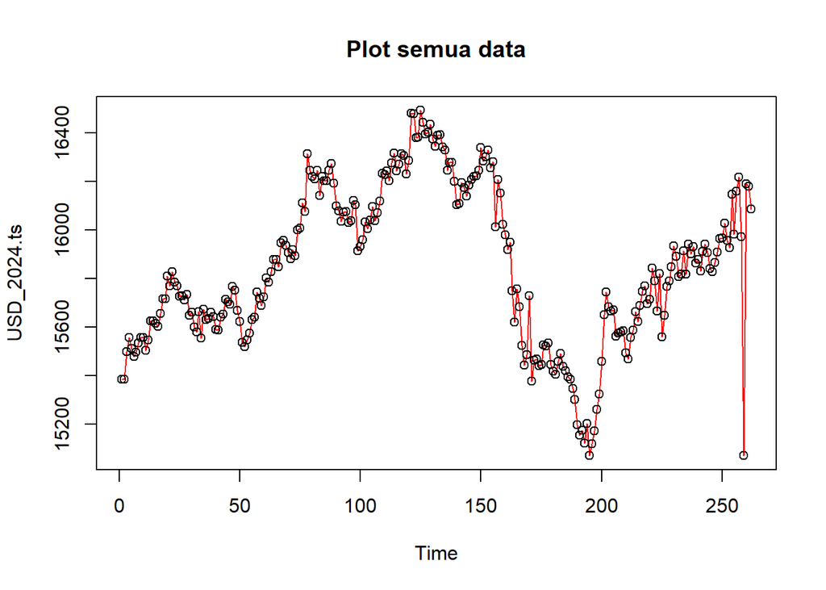

```r
plot(USD_2024.ts, col="red",main="Plot semua data")
points(USD_2024.ts)
```

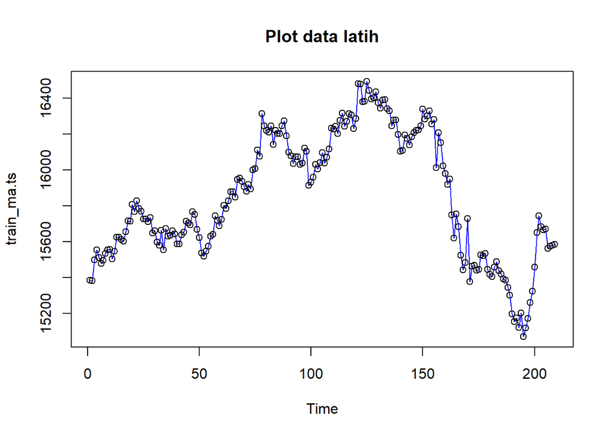

```r
plot(train_ma.ts, col="blue",main="Plot data latih")
points(train_ma.ts)
```

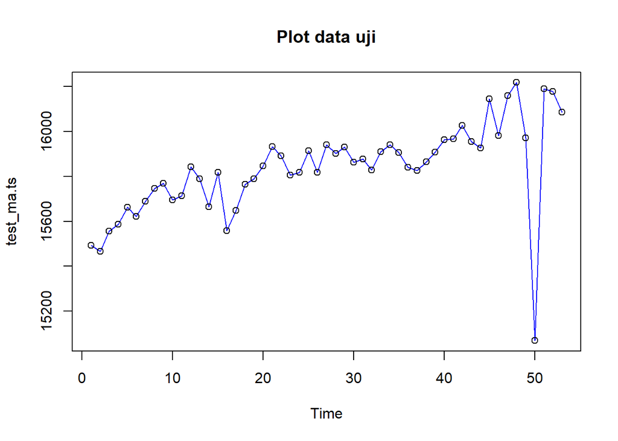

```r
plot(test_ma.ts, col="blue",main="Plot data uji")
points(test_ma.ts)
```

Eksplorasi data juga dapat dilakukan menggunakan package ggplot2 dengan terlebih dahulu memanggil library package ggplot2.

```r
library(ggplot2)
```

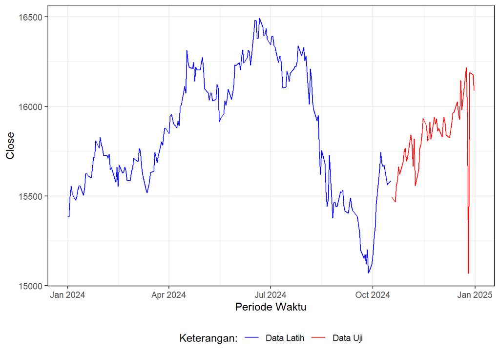

```r
ggplot() +
  geom_line(data = training_ma, aes(x = Date, y = Close, col = "Data Latih")) +
  geom_line(data = testing_ma, aes(x = Date, y = Close, col = "Data Uji")) +
  labs(x = "Periode Waktu", y = "Close", color = "Legend") +
   scale_colour_manual(name="Keterangan:", breaks = c("Data Latih", "Data Uji"),
                      values = c("blue", "red")) +
  theme_bw() + theme(legend.position = "bottom",
                     plot.caption = element_text(hjust=0.5, size=12))
```

## Single Moving Average (SMA)

Pemulusan menggunakan metode SMA dilakukan dengan fungsi SMA(). Dalam hal ini akan dilakukan pemulusan dengan parameter m=3

```r
data.sma<-SMA(train_ma.ts, n=3)
data.sma
```

```
## Time Series:
## Start = 1
## End = 209
## Frequency = 1
##   [1]       NA       NA 15421.37 15478.67 15521.33 15514.50 15494.67 15502.50
##   [9] 15528.33 15548.67 15538.23 15535.23 15558.07 15598.33 15620.70 15612.70
##  [17] 15623.20 15657.17 15695.00 15745.83 15763.37 15801.20 15793.53 15794.00
##  [25] 15760.00 15740.73 15721.57 15723.90 15697.17 15680.10 15635.10 15612.60
##  [33] 15613.00 15598.03 15628.87 15617.90 15644.87 15641.20 15645.67 15630.33
##  [41] 15605.37 15604.20 15625.87 15667.90 15689.73 15702.70 15720.63 15736.47
##  [49] 15728.50 15680.17 15608.43 15558.43 15533.43 15546.00 15583.33 15614.43
##  [57] 15670.77 15700.10 15716.00 15709.50 15737.70 15770.03 15804.87 15829.67
##  [65] 15860.67 15867.33 15890.27 15916.27 15945.60 15931.83 15907.17 15901.17
##  [73] 15897.10 15936.17 15965.83 16038.73 16064.33 16166.07 16211.07 16259.40
##  [81] 16225.43 16225.43 16198.83 16202.07 16187.40 16208.33 16217.00 16240.67
```

[output cut: 16 more lines]

```r
data.ramal<-c(NA,data.sma)
data.ramal
```

```
##   [1]       NA       NA       NA 15421.37 15478.67 15521.33 15514.50 15494.67
##   [9] 15502.50 15528.33 15548.67 15538.23 15535.23 15558.07 15598.33 15620.70
##  [17] 15612.70 15623.20 15657.17 15695.00 15745.83 15763.37 15801.20 15793.53
##  [25] 15794.00 15760.00 15740.73 15721.57 15723.90 15697.17 15680.10 15635.10
##  [33] 15612.60 15613.00 15598.03 15628.87 15617.90 15644.87 15641.20 15645.67
##  [41] 15630.33 15605.37 15604.20 15625.87 15667.90 15689.73 15702.70 15720.63
##  [49] 15736.47 15728.50 15680.17 15608.43 15558.43 15533.43 15546.00 15583.33
##  [57] 15614.43 15670.77 15700.10 15716.00 15709.50 15737.70 15770.03 15804.87
##  [65] 15829.67 15860.67 15867.33 15890.27 15916.27 15945.60 15931.83 15907.17
##  [73] 15901.17 15897.10 15936.17 15965.83 16038.73 16064.33 16166.07 16211.07
##  [81] 16259.40 16225.43 16225.43 16198.83 16202.07 16187.40 16208.33 16217.00
##  [89] 16240.67 16236.47 16186.80 16121.47 16069.33 16061.33 16060.33 16059.00
##  [97] 16047.33 16063.00 16087.00 16045.67 15982.27 15934.27 15973.27 15998.00
## [105] 16025.57 16046.90 16057.90 16068.00 16075.33 16140.03 16192.37 16234.37
## [113] 16224.67 16240.67 16264.67 16277.57 16275.57 16274.57 16295.80 16282.47
## [121] 16273.80 16331.97 16414.97 16445.97 16412.97 16417.27 16438.60 16443.00
## [129] 16412.70 16409.70 16403.13 16383.80 16369.13 16374.67 16373.67 16353.17
## [137] 16304.50 16283.57 16266.40 16250.73 16193.00 16136.67 16135.67 16158.67
## [145] 16168.67 16165.33 16176.33 16203.73 16216.07 16229.40 16268.60 16288.93
## [153] 16307.50 16304.40 16295.07 16288.17 16182.67 16167.00 16124.10 16127.77
## [161] 16051.43 15973.33 15948.70 15872.03 15772.53 15707.83 15685.83 15653.67
## [169] 15549.33 15483.00 15551.50 15529.90 15522.77 15435.63 15456.57 15450.63
## [177] 15469.93 15496.63 15526.00 15499.13 15464.77 15422.13 15426.27 15450.27
## [185] 15460.93 15448.23 15416.23 15398.90 15374.33 15343.40 15280.93 15217.27
## [193] 15175.23 15149.73 15165.57 15130.87 15129.83 15119.53 15183.07 15251.73
## [201] 15347.20 15477.00 15617.00 15692.13 15697.00 15672.63 15632.50 15601.97
## [209] 15571.20 15578.50
```

Selanjutnya dilakukan peramalan sebanyak 53 periode sesuai dengan jumlah data uji. Pada metode SMA, seluruh hasil peramalan untuk 53 periode ke depan akan memiliki nilai yang sama dengan hasil ramalan satu periode ke depan.

```r
data.gab<-cbind(
  aktual=c(USD_2024.ts),
  pemulusan=c(data.sma,rep(NA,53)),
  ramalan=c(data.ramal,rep(data.ramal[length(data.ramal)],52)))

data.gab
```

```
##         aktual pemulusan  ramalan
##   [1,] 15383.1        NA       NA
##   [2,] 15383.0        NA       NA
##   [3,] 15498.0  15421.37       NA
##   [4,] 15555.0  15478.67 15421.37
##   [5,] 15511.0  15521.33 15478.67
##   [6,] 15477.5  15514.50 15521.33
##   [7,] 15495.5  15494.67 15514.50
##   [8,] 15534.5  15502.50 15494.67
##   [9,] 15555.0  15528.33 15502.50
##  [10,] 15556.5  15548.67 15528.33
##  [11,] 15503.2  15538.23 15548.67
##  [12,] 15546.0  15535.23 15538.23
##  [13,] 15625.0  15558.07 15535.23
##  [14,] 15624.0  15598.33 15558.07
```

[output cut: 248 more lines]

Adapun plot data deret waktu dari hasil peramalan yang dilakukan adalah sebagai berikut.

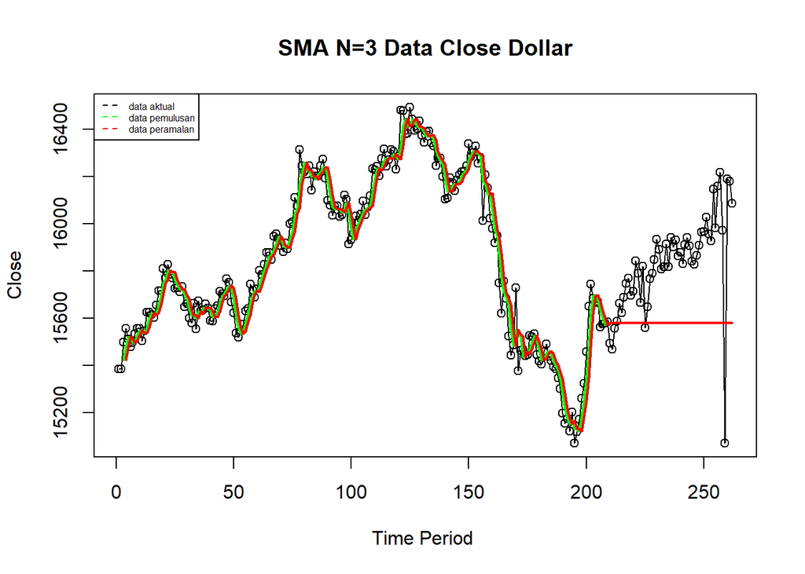

```r
ts.plot(USD_2024.ts, xlab="Time Period ", ylab="Close", main= "SMA N=3 Data Close Dollar")
points(USD_2024.ts)
lines(data.gab[,2],col="green",lwd=2)
lines(data.gab[,3],col="red",lwd=2)
legend("topleft",c("data aktual","data pemulusan","data peramalan"), lty=8, col=c("black","green","red"), cex=0.5)
```

Selanjutnya perhitungan akurasi dilakukan dengan ukuran akurasi Sum Squares Error (SSE), Mean Square Error (MSE) dan Mean Absolute Percentage Error (MAPE). Perhitungan akurasi dilakukan baik pada data latih maupun pada data uji.

```r
error_train.sma = train_ma.ts-data.ramal[1:length(train_ma.ts)]

SSE_train.sma = sum(error_train.sma[5:length(train_ma.ts)]^2)
MSE_train.sma = mean(error_train.sma[5:length(train_ma.ts)]^2)
MAPE_train.sma = mean(abs((error_train.sma[5:length(train_ma.ts)]/train_ma.ts[5:length(train_ma.ts)])*100))

akurasi_train.sma <- matrix(c(SSE_train.sma, MSE_train.sma, MAPE_train.sma))
row.names(akurasi_train.sma)<- c("SSE", "MSE", "MAPE")
colnames(akurasi_train.sma) <- c("Akurasi m = 3")
akurasi_train.sma
```

```
##      Akurasi m = 3
## SSE   1.448369e+06
## MSE   7.065217e+03
## MAPE  3.951218e-01
```

```r
#Menghitung nilai keakuratan data uji
error_test.sma = test_ma.ts-data.gab[210:262,3]

SSE_test.sma = sum(error_test.sma^2)
MSE_test.sma = mean(error_test.sma^2)
MAPE_test.sma = mean(abs((error_test.sma/test_ma.ts*100)))

akurasi_test.sma <- matrix(c(SSE_test.sma, MSE_test.sma, MAPE_test.sma))
row.names(akurasi_test.sma)<- c("SSE", "MSE", "MAPE")
colnames(akurasi_test.sma) <- c("Akurasi m = 3")
akurasi_test.sma
```

```
##      Akurasi m = 3
## SSE   5.627286e+06
## MSE   1.061752e+05
## MAPE  1.791174e+00
```

Perhitungan akurasi menggunakan data latih menghasilkan nilai MAPE yang kurang dari 10% sehingga nilai akurasi ini dapat dikategorikan sebagai sangat baik.

# Double Moving Average

Metode pemulusan Double Moving Average (DMA) pada dasarnya mirip dengan SMA. Namun demikian, metode ini lebih cocok digunakan untuk pola data trend. Proses pemulusan dengan rata rata dalam metode ini dilakukan sebanyak 2 kali.

```r
dma <- SMA(data.sma, n = 3)
At <- 2*data.sma - dma
Bt <- 2/(3-1)*(data.sma - dma)
data.dma<- At+Bt
data.ramal2<- c(NA, data.dma)

t = 1:53
f = c()

for (i in t) {
  f[i] = At[length(At)] + Bt[length(Bt)]*(i)
}

data.gab2 <- cbind(aktual = c(USD_2024.ts),
                   pemulusan1 = c(data.sma,rep(NA,53)),
                   pemulusan2 = c(dma, rep(NA,53)),
                   At = c(At, rep(NA,53)),
                   Bt = c(Bt,rep(NA,53)),
                   ramalan = c(data.ramal2, f[-1]))
data.gab2
```

```
##         aktual pemulusan1 pemulusan2       At           Bt  ramalan
##   [1,] 15383.1         NA         NA       NA           NA       NA
##   [2,] 15383.0         NA         NA       NA           NA       NA
##   [3,] 15498.0   15421.37         NA       NA           NA       NA
##   [4,] 15555.0   15478.67         NA       NA           NA       NA
##   [5,] 15511.0   15521.33   15473.79 15568.88  47.54448785       NA
##   [6,] 15477.5   15514.50   15504.83 15524.17   9.66666667 15616.42
##   [7,] 15495.5   15494.67   15510.17 15479.17 -15.50000000 15533.83
##   [8,] 15534.5   15502.50   15503.89 15501.11  -1.38888889 15463.67
##   [9,] 15555.0   15528.33   15508.50 15548.17  19.83333333 15499.72
##  [10,] 15556.5   15548.67   15526.50 15570.83  22.16666667 15568.00
##  [11,] 15503.2   15538.23   15538.41 15538.06  -0.17773438 15593.00
##  [12,] 15546.0   15535.23   15540.71 15529.76  -5.47775608 15537.88
##  [13,] 15625.0   15558.07   15543.84 15572.29  14.22222222 15524.28
##  [14,] 15624.0   15598.33   15563.88 15632.79  34.45551215 15586.51
```

[output cut: 248 more lines]

Hasil pemulusan menggunakan metode DMA divisualisasikan sebagai berikut

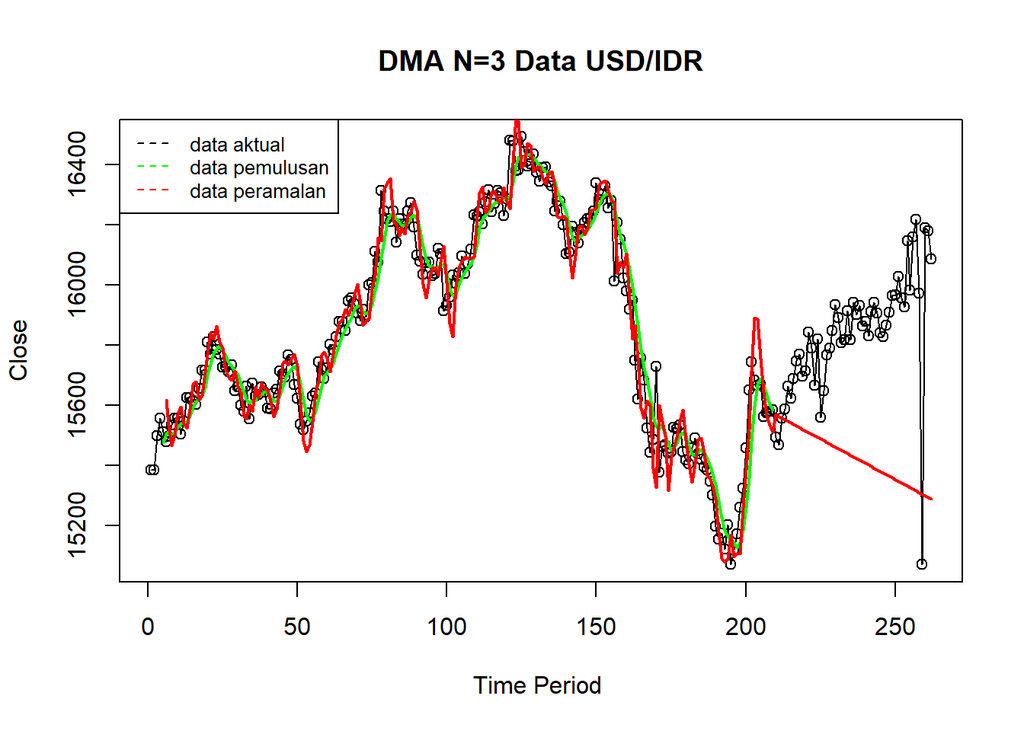

```r
ts.plot(USD_2024.ts, xlab="Time Period ", ylab="Close", main= "DMA N=3 Data USD/IDR")
points(USD_2024.ts)
lines(data.gab2[,3],col="green",lwd=2)
lines(data.gab2[,6],col="red",lwd=2)
legend("topleft",c("data aktual","data pemulusan","data peramalan"), lty=8, col=c("black","green","red"), cex=0.8)
```

Selanjutnya perhitungan akurasi dilakukan baik pada data latih maupun data uji. Perhitungan akurasi dilakukan dengan ukuran akurasi SSE, MSE dan MAPE.

```r
error_train.dma = train_ma.ts-data.ramal2[1:length(train_ma.ts)]

SSE_train.dma = sum(error_train.dma[8:length(train_ma.ts)]^2)
MSE_train.dma = mean(error_train.dma[8:length(train_ma.ts)]^2)
MAPE_train.dma = mean(abs((error_train.dma[8:length(train_ma.ts)]/train_ma.ts[8:length(train_ma.ts)])*100))

akurasi_train.dma <- matrix(c(SSE_train.dma, MSE_train.dma, MAPE_train.dma))
row.names(akurasi_train.dma)<- c("SSE", "MSE", "MAPE")
colnames(akurasi_train.dma) <- c("Akurasi m = 3")
akurasi_train.dma
```

```
##      Akurasi m = 3
## SSE   1.549813e+06
## MSE   7.672341e+03
## MAPE  4.249136e-01
```

Perhitungan akurasi pada data latih menggunakan nilai MAPE menghasilkan nilai MAPE yang kurang dari 10% sehingga dikategorikan sangat baik. Selanjutnya, perhitungan nilai akurasi dilakukan pada data uji.

```r
error_test.dma = test_ma.ts-data.gab2[210:262,6]
SSE_test.dma = sum(error_test.dma^2)
MSE_test.dma = mean(error_test.dma^2)
MAPE_test.dma = mean(abs((error_test.dma/test_ma.ts*100)))

akurasi_test.dma <- matrix(c(SSE_test.dma, MSE_test.dma, MAPE_test.dma))
row.names(akurasi_test.dma)<- c("SSE", "MSE", "MAPE")
colnames(akurasi_test.dma) <- c("Akurasi m = 3")
akurasi_test.dma
```

```
##      Akurasi m = 3
## SSE   1.239898e+07
## MSE   2.339429e+05
## MAPE  2.654513e+00
```

Pada kedua data metode SMA lebih baik dibandingkan dengan metode DMA.

# Single Exponential Smoothing & Double Exponential Smoothing

Metode Exponential Smoothing merupakan metode pemulusan deret waktu dengan memberikan bobot yang menurun secara eksponensial pada data historis, di mana nilai terbaru mendapat bobot lebih besar dibanding nilai yang lebih lama. Metode ini menggunakan satu atau lebih parameter pemulusan yang secara langsung menentukan besar kecilnya bobot setiap pengamatan. Pemilihan parameter yang tepat akan sangat berpengaruh terhadap hasil ramalan. Secara umum, Exponential Smoothing dibedakan menjadi dua jenis, yaitu model tunggal (single) yang digunakan untuk data tanpa tren maupun musiman, serta model ganda (double) yang mampu menangkap adanya tren pada data.

## Pembagian Data

Pembagian data latih dan data uji dilakukan dengan perbandingan 80% data latih dan 20% data uji.

```r
# jumlah baris data
n <- nrow(USD_2024)

# hitung batas 80%
n_train <- floor(0.8 * n)

# bagi data
training <- USD_2024[1:n_train, ]
testing  <- USD_2024[(n_train+1):n, ]

# ubah ke time series
train.ts <- ts(training$Close)
test.ts  <- ts(testing$Close)
```

## Single Exponential Smoothing

Single Exponential Smoothing (SES) adalah metode peramalan deret waktu yang dikembangkan untuk mengatasi kelemahan Moving Average. Jika pada Moving Average setiap data periode sebelumnya dianggap memiliki bobot yang sama, maka SES memberikan bobot yang semakin mengecil secara eksponensial terhadap data lama, sehingga data terbaru diberi bobot lebih besar.

Single Exponential Smoothing merupakan metode pemulusan yang tepat digunakan untuk data dengan pola stasioner atau konstan.

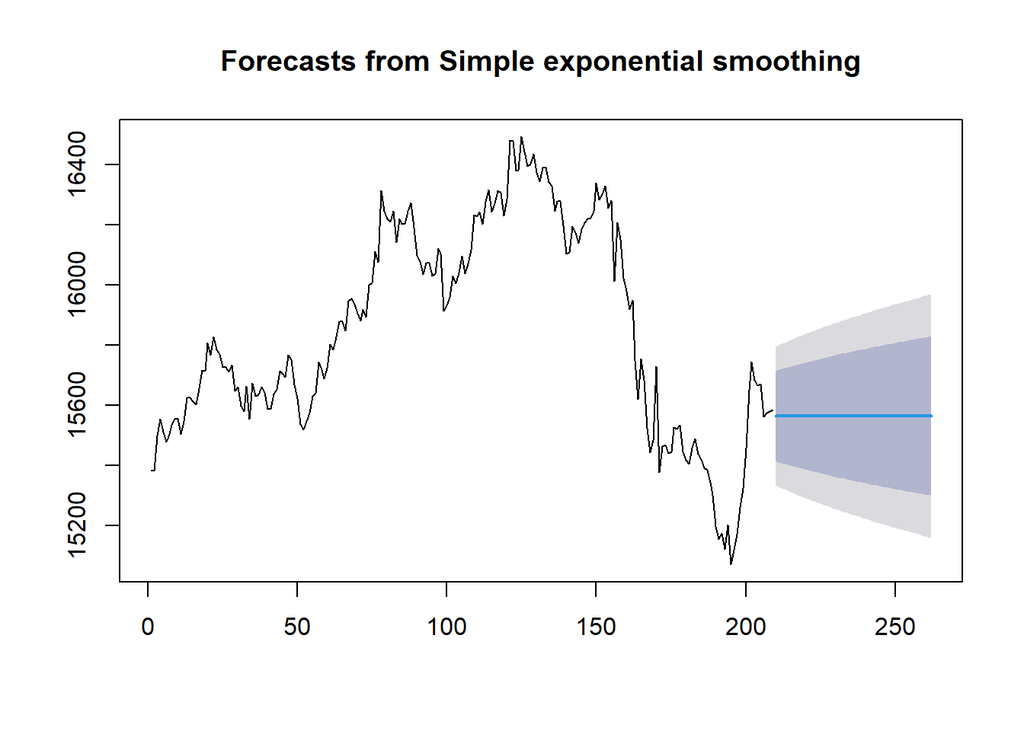

```r
#Cara 1 (fungsi ses)
ses.1 <- ses(train.ts, h = 53, alpha = 0.2)
plot(ses.1)
```

```r
ses.1
```

```
##     Point Forecast    Lo 80    Hi 80    Lo 95    Hi 95
## 210       15564.04 15413.46 15714.62 15333.75 15794.33
## 211       15564.04 15410.48 15717.60 15329.19 15798.89
## 212       15564.04 15407.56 15720.53 15324.72 15803.37
## 213       15564.04 15404.68 15723.40 15320.33 15807.76
## 214       15564.04 15401.86 15726.22 15316.01 15812.07
## 215       15564.04 15399.09 15728.99 15311.77 15816.31
## 216       15564.04 15396.37 15731.72 15307.60 15820.48
## 217       15564.04 15393.68 15734.40 15303.50 15824.59
## 218       15564.04 15391.04 15737.05 15299.46 15828.63
## 219       15564.04 15388.44 15739.65 15295.48 15832.61
## 220       15564.04 15385.88 15742.21 15291.56 15836.53
## 221       15564.04 15383.35 15744.74 15287.69 15840.39
## 222       15564.04 15380.86 15747.23 15283.88 15844.20
## 223       15564.04 15378.40 15749.69 15280.12 15847.96
```

[output cut: 39 more lines]

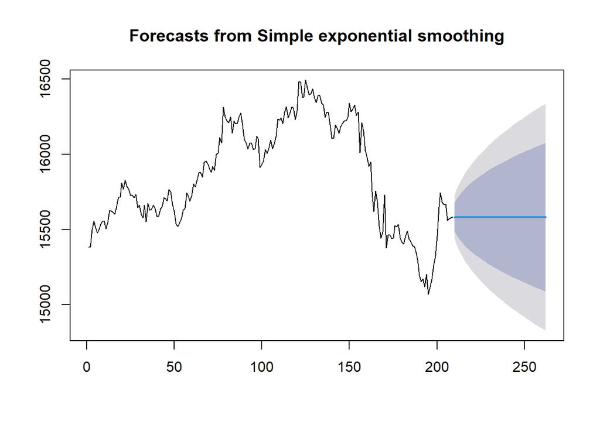

```r
ses.2<- ses(train.ts, h = 53, alpha = 0.7)
plot(ses.2)
```

```r
ses.2
```

```
##     Point Forecast    Lo 80    Hi 80    Lo 95    Hi 95
## 210       15582.39 15486.69 15678.09 15436.03 15728.76
## 211       15582.39 15465.57 15699.21 15403.73 15761.05
## 212       15582.39 15447.73 15717.06 15376.44 15788.35
## 213       15582.39 15431.98 15732.80 15352.36 15812.42
## 214       15582.39 15417.74 15747.05 15330.58 15834.21
## 215       15582.39 15404.63 15760.15 15310.53 15854.25
## 216       15582.39 15392.43 15772.36 15291.86 15872.92
## 217       15582.39 15380.96 15783.82 15274.33 15890.45
## 218       15582.39 15370.11 15794.67 15257.74 15907.05
## 219       15582.39 15359.79 15804.99 15241.95 15922.83
## 220       15582.39 15349.93 15814.85 15226.87 15937.91
## 221       15582.39 15340.47 15824.31 15212.40 15952.38
## 222       15582.39 15331.36 15833.42 15198.48 15966.30
## 223       15582.39 15322.58 15842.20 15185.04 15979.74
```

[output cut: 39 more lines]

Pada fungsi ses() , terdapat beberapa argumen yang umum digunakan, yaitu

y : nilai data deret waktu

alpha : parameter pemulusan utama (0–1), mengatur bobot data terbaru vs data lama.

beta : parameter pemulusan tren.

gamma : parameter pemulusan musiman.

h : jumlah periode ke depan yang ingin diramalkan (forecast horizon).

Untuk mendapatkan gambar hasil pemulusan pada data latih dengan fungsi ses() , perlu digunakan fungsi autoplot() dan autolayer() dari library packages ggplot2 .

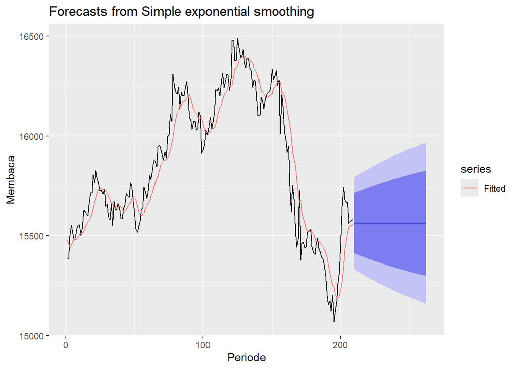

```r
autoplot(ses.1) +
  autolayer(fitted(ses.1), series="Fitted") +
  ylab("Membaca") + xlab("Periode")
```

Selanjutnya akan digunakan fungsi HoltWinters() dengan nilai inisialisasi parameter dan panjang periode peramalan yang sama dengan fungsi ses() .

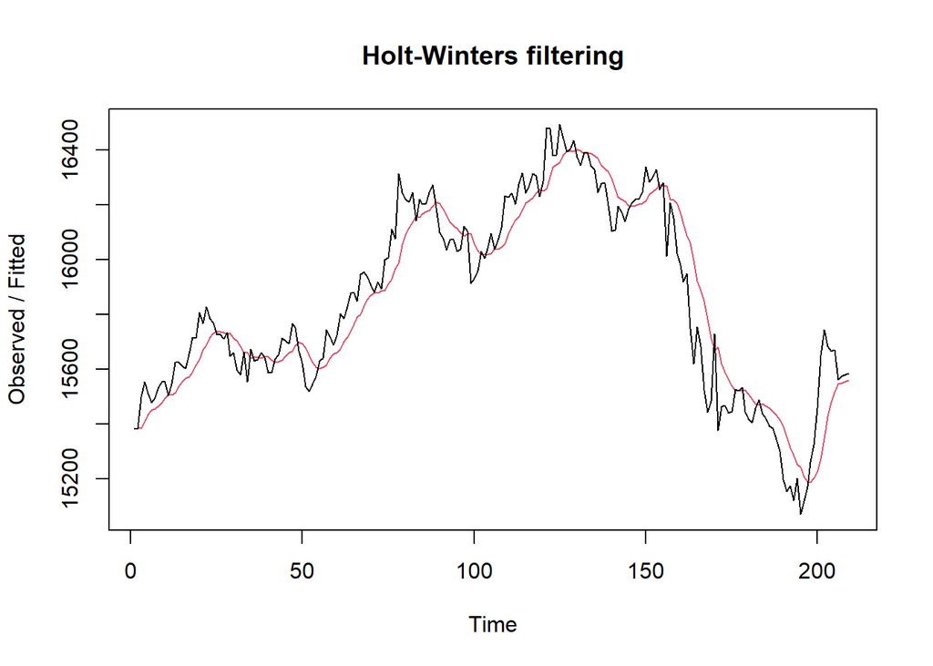

```r
ses1<- HoltWinters(train.ts, gamma = FALSE, beta = FALSE, alpha = 0.2)
plot(ses1)
```

```r
ramalan1<- forecast(ses1, h=53)
ramalan1
```

```
##     Point Forecast    Lo 80    Hi 80    Lo 95    Hi 95
## 210       15564.04 15412.89 15715.19 15332.88 15795.21
## 211       15564.04 15409.90 15718.19 15328.30 15799.79
## 212       15564.04 15406.96 15721.12 15323.81 15804.28
## 213       15564.04 15404.08 15724.01 15319.40 15808.69
## 214       15564.04 15401.25 15726.84 15315.07 15813.02
## 215       15564.04 15398.47 15729.62 15310.81 15817.27
## 216       15564.04 15395.73 15732.36 15306.63 15821.46
## 217       15564.04 15393.03 15735.05 15302.51 15825.58
## 218       15564.04 15390.38 15737.70 15298.45 15829.63
## 219       15564.04 15387.77 15740.31 15294.46 15833.63
## 220       15564.04 15385.20 15742.89 15290.52 15837.56
## 221       15564.04 15382.66 15745.42 15286.64 15841.44
## 222       15564.04 15380.16 15747.93 15282.82 15845.27
## 223       15564.04 15377.69 15750.39 15279.04 15849.04
```

[output cut: 39 more lines]

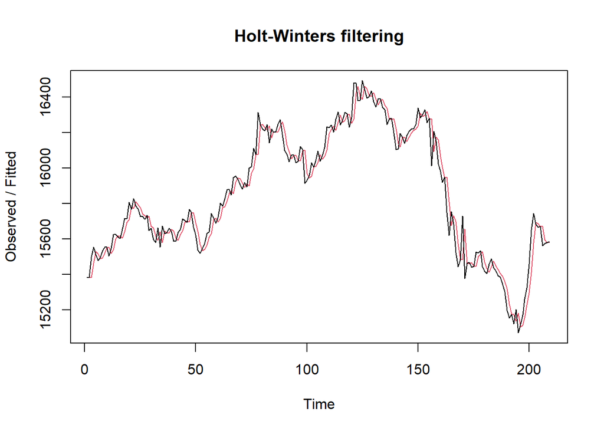

```r
ses2<- HoltWinters(train.ts, gamma = FALSE, beta = FALSE, alpha = 0.7)
plot(ses2)
```

```r
ramalan2<- forecast(ses2, h=53)
ramalan2
```

```
##     Point Forecast    Lo 80    Hi 80    Lo 95    Hi 95
## 210       15582.39 15486.70 15678.08 15436.04 15728.74
## 211       15582.39 15465.58 15699.20 15403.75 15761.03
## 212       15582.39 15447.74 15717.04 15376.46 15788.32
## 213       15582.39 15432.00 15732.78 15352.38 15812.40
## 214       15582.39 15417.76 15747.03 15330.60 15834.18
## 215       15582.39 15404.65 15760.13 15310.56 15854.22
## 216       15582.39 15392.45 15772.34 15291.90 15872.89
## 217       15582.39 15380.98 15783.80 15274.36 15890.42
## 218       15582.39 15370.13 15794.65 15257.77 15907.01
## 219       15582.39 15359.82 15804.97 15241.99 15922.79
## 220       15582.39 15349.95 15814.83 15226.91 15937.87
## 221       15582.39 15340.49 15824.29 15212.44 15952.34
## 222       15582.39 15331.39 15833.39 15198.52 15966.26
## 223       15582.39 15322.61 15842.18 15185.08 15979.70
```

[output cut: 39 more lines]

Fungsi HoltWinters memiliki argumen yang sama dengan fungsi ses() . Argumen-argumen kedua fungsi dapat dilihat lebih lanjut dengan ?ses() atau ?HoltWinters .

Nilai parameter α dari kedua fungsi dapat dioptimalkan menyesuaikan dari error-nya paling minimumnya. Caranya adalah dengan membuat parameter α= NULL .

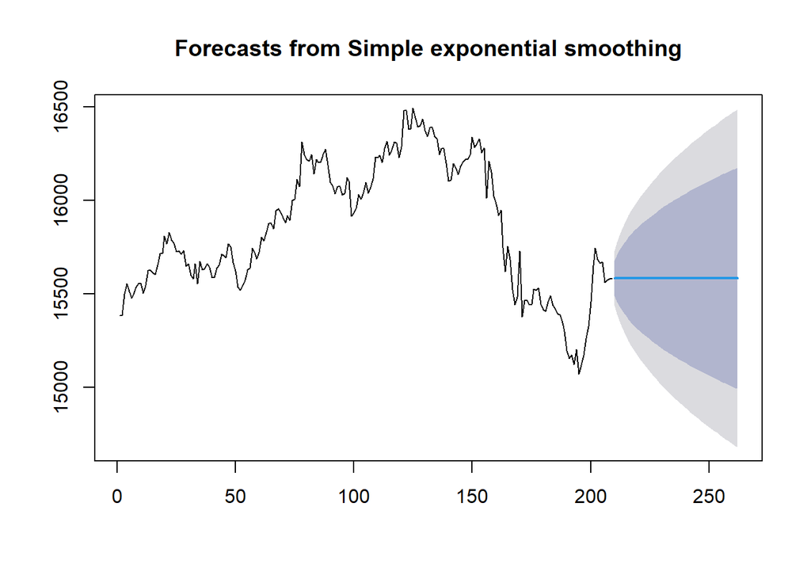

```r
ses.opt <- ses(train.ts, h = 53, alpha = NULL)
plot(ses.opt)
```

```r
ses.opt
```

```
##     Point Forecast    Lo 80    Hi 80    Lo 95    Hi 95
## 210       15583.05 15488.71 15677.38 15438.77 15727.32
## 211       15583.05 15458.76 15707.33 15392.97 15773.12
## 212       15583.05 15434.74 15731.35 15356.24 15809.85
## 213       15583.05 15414.11 15751.99 15324.68 15841.42
## 214       15583.05 15395.73 15770.36 15296.57 15869.52
## 215       15583.05 15379.00 15787.09 15270.98 15895.11
## 216       15583.05 15363.54 15802.55 15247.34 15918.75
## 217       15583.05 15349.10 15816.99 15225.26 15940.83
## 218       15583.05 15335.50 15830.59 15204.46 15961.63
## 219       15583.05 15322.62 15843.48 15184.75 15981.34
## 220       15583.05 15310.34 15855.76 15165.97 16000.12
## 221       15583.05 15298.58 15867.51 15148.00 16018.09
## 222       15583.05 15287.30 15878.79 15130.74 16035.35
## 223       15583.05 15276.43 15889.66 15114.12 16051.97
```

[output cut: 39 more lines]

```r
#Lamda Optimum Holt Winter
HWopt<- HoltWinters(train.ts, gamma = FALSE, beta = FALSE,alpha = NULL)
HWopt
```

```
## Holt-Winters exponential smoothing without trend and without seasonal component.
##
## Call:
## HoltWinters(x = train.ts, alpha = NULL, beta = FALSE, gamma = FALSE)
##
## Smoothing parameters:
##  alpha: 0.8578073
##  beta : FALSE
##  gamma: FALSE
##
## Coefficients:
##       [,1]
## a 15583.05
```

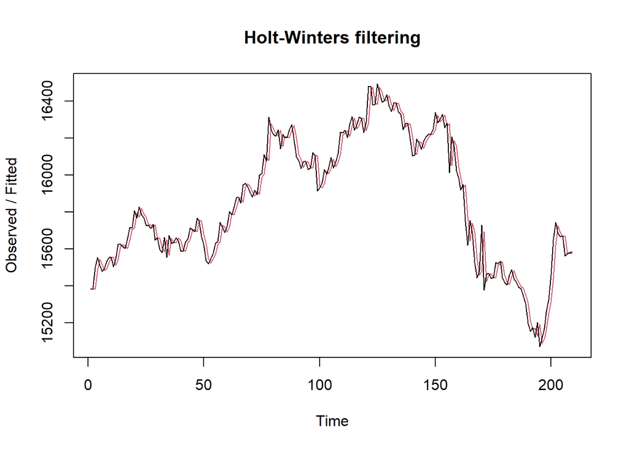

```r
plot(HWopt)
```

```r
ramalanopt<- forecast(HWopt, h=53)
ramalanopt
```

```
##     Point Forecast    Lo 80    Hi 80    Lo 95    Hi 95
## 210       15583.05 15488.72 15677.37 15438.79 15727.30
## 211       15583.05 15458.77 15707.32 15392.99 15773.10
## 212       15583.05 15434.76 15731.34 15356.25 15809.84
## 213       15583.05 15414.12 15751.97 15324.69 15841.40
## 214       15583.05 15395.74 15770.35 15296.59 15869.51
## 215       15583.05 15379.01 15787.08 15271.00 15895.09
## 216       15583.05 15363.55 15802.54 15247.36 15918.73
## 217       15583.05 15349.12 15816.98 15225.28 15940.81
## 218       15583.05 15335.52 15830.57 15204.48 15961.61
## 219       15583.05 15322.63 15843.46 15184.77 15981.32
## 220       15583.05 15310.35 15855.74 15165.99 16000.10
## 221       15583.05 15298.60 15867.49 15148.02 16018.07
## 222       15583.05 15287.32 15878.78 15130.76 16035.33
## 223       15583.05 15276.45 15889.65 15114.14 16051.95
```

[output cut: 39 more lines]

Setelah dilakukan peramalan, akan dilakukan perhitungan keakuratan hasil peramalan. Perhitungan akurasi ini dilakukan baik pada data latih dan data uji.

Perhitungan akurasi data dapat dilakukan dengan cara langsung maupun manual. Secara langsung, nilai akurasi dapat diambil dari objek yang tersimpan pada hasil SES, yaitu sum of squared errors (SSE). Nilai akurasi lain dapat dihitung pula dari nilai SSE tersebut.

```r
SSE1<-ses1$SSE
MSE1<-ses1$SSE/length(train.ts)
RMSE1<-sqrt(MSE1)

akurasi1 <- matrix(c(SSE1,MSE1,RMSE1))
row.names(akurasi1)<- c("SSE", "MSE", "RMSE")
colnames(akurasi1) <- c("Akurasi lamda=0.2")
akurasi1
```

```
##      Akurasi lamda=0.2
## SSE       2883467.1026
## MSE         13796.4933
## RMSE          117.4585
```

```r
SSE2<-ses2$SSE
MSE2<-ses2$SSE/length(train.ts)
RMSE2<-sqrt(MSE2)

akurasi2 <- matrix(c(SSE2,MSE2,RMSE2))
row.names(akurasi2)<- c("SSE", "MSE", "RMSE")
colnames(akurasi2) <- c("Akurasi lamda=0.7")
akurasi2
```

```
##      Akurasi lamda=0.7
## SSE       1.154529e+06
## MSE       5.524063e+03
## RMSE      7.432404e+01
```

```r
SSE1<-ses1$SSE
SSE1
```

```
## [1] 2883467
```

```r
fitted1<-ramalan1$fitted
sisaan1<-ramalan1$residuals
head(sisaan1)
```

```
## Time Series:
## Start = 1
## End = 6
## Frequency = 1
## [1]           NA  -0.09960938 114.92031250 148.93625000  75.14900000
## [6]  26.61920000
```

```r
resid1<-training$Close-ramalan1$fitted
head(resid1)
```

```
## Time Series:
## Start = 1
## End = 6
## Frequency = 1
## [1]           NA  -0.09960938 114.92031250 148.93625000  75.14900000
## [6]  26.61920000
```

```r
SSE.1=sum(sisaan1[2:length(train.ts)]^2)
SSE.1
```

```
## [1] 2883467
```

```r
MSE.1 = SSE.1/length(train.ts)
MSE.1
```

```
## [1] 13796.49
```

```r
MAPE.1 = sum(abs(sisaan1[2:length(train.ts)]/train.ts[2:length(train.ts)])*
               100)/length(train.ts)
MAPE.1
```

```
## [1] 0.5582543
```

```r
akurasi.1 <- matrix(c(SSE.1,MSE.1,MAPE.1))
row.names(akurasi.1)<- c("SSE", "MSE", "MAPE")
colnames(akurasi.1) <- c("Akurasi lamda=0.2")
akurasi.1
```

```
##      Akurasi lamda=0.2
## SSE       2.883467e+06
## MSE       1.379649e+04
## MAPE      5.582543e-01
```

```r
fitted2<-ramalan2$fitted
sisaan2<-ramalan2$residuals
head(sisaan2)
```

```
## Time Series:
## Start = 1
## End = 6
## Frequency = 1
## [1]           NA  -0.09960938 114.97011719  91.49103516 -16.55268945
## [6] -38.46580684
```

```r
resid2<-training$Close-ramalan2$fitted
head(resid2)
```

```
## Time Series:
## Start = 1
## End = 6
## Frequency = 1
## [1]           NA  -0.09960938 114.97011719  91.49103516 -16.55268945
## [6] -38.46580684
```

```r
SSE.2=sum(sisaan2[2:length(train.ts)]^2)
SSE.2
```

```
## [1] 1154529
```

```r
MSE.2 = SSE.2/length(train.ts)
MSE.2
```

```
## [1] 5524.063
```

```r
MAPE.2 = sum(abs(sisaan2[2:length(train.ts)]/train.ts[2:length(train.ts)])*
               100)/length(train.ts)
MAPE.2
```

```
## [1] 0.3348284
```

```r
akurasi.2 <- matrix(c(SSE.2,MSE.2,MAPE.2))
row.names(akurasi.2)<- c("SSE", "MSE", "MAPE")
colnames(akurasi.2) <- c("Akurasi lamda=0.7")
akurasi.2
```

```
##      Akurasi lamda=0.7
## SSE       1.154529e+06
## MSE       5.524063e+03
## MAPE      3.348284e-01
```

Akurasi data uji dapat dihitung dengan cara yang hampir sama dengan perhitungan akurasi data latih.

```r
n_test <- nrow(testing)

# error (ramalan - aktual), samakan panjang dan tipe numeric
e1   <- as.numeric(ramalan1$mean)[1:n_test] - as.numeric(testing$Close)
e2   <- as.numeric(ramalan2$mean)[1:n_test] - as.numeric(testing$Close)
eopt <- as.numeric(ramalanopt$mean)[1:n_test] - as.numeric(testing$Close)

# SSE / MSE / RMSE untuk masing-masing model (abaikan NA)
SSEtesting1  <- sum(e1^2,  na.rm = TRUE)
MSEtesting1  <- mean(e1^2, na.rm = TRUE)
RMSEtesting1 <- sqrt(MSEtesting1)

SSEtesting2  <- sum(e2^2,  na.rm = TRUE)
MSEtesting2  <- mean(e2^2, na.rm = TRUE)
RMSEtesting2 <- sqrt(MSEtesting2)

SSEtestingopt  <- sum(eopt^2,  na.rm = TRUE)
MSEtestingopt  <- mean(eopt^2, na.rm = TRUE)
RMSEtestingopt <- sqrt(MSEtestingopt)

# Tabel ringkas
akurasitesting_SSE <- matrix(c(SSEtesting1, SSEtesting2, SSEtestingopt),
                             nrow = 3,
                             dimnames = list(c("SSE1","SSE2","SSEopt"), "Nilai"))
akurasitesting_MSE <- matrix(c(MSEtesting1, MSEtesting2, MSEtestingopt),
                             nrow = 3,
                             dimnames = list(c("MSE1","MSE2","MSEopt"), "Nilai"))
akurasitesting_RMSE <- matrix(c(RMSEtesting1, RMSEtesting2, RMSEtestingopt),
                              nrow = 3,
                              dimnames = list(c("RMSE1","RMSE2","RMSEopt"), "Nilai"))

akurasitesting_SSE
```

```
##          Nilai
## SSE1   6031778
## SSE2   5522190
## SSEopt 5504667
```

```r
akurasitesting_MSE
```

```
##           Nilai
## MSE1   113807.1
## MSE2   104192.3
## MSEopt 103861.6
```

```r
akurasitesting_RMSE
```

```
##            Nilai
## RMSE1   337.3531
## RMSE2   322.7883
## RMSEopt 322.2757
```

```r
accuracy(ramalan1, testing$Close)
```

```
##                      ME     RMSE       MAE        MPE      MAPE     MASE
## Training set   4.349601 117.7405  88.65769 0.02309454 0.5609382 1.667974
## Test set     271.181480 337.3531 296.72166 1.69654130 1.8648034 5.582416
##                   ACF1
## Training set 0.7767221
## Test set            NA
```

```r
accuracy(ramalan2, testing$Close)
```

```
##                      ME      RMSE       MAE         MPE      MAPE     MASE
## Training set   1.368763  74.50249  53.24591 0.007397106 0.3364382 1.001750
## Test set     252.832997 322.78826 281.83515 1.580651153 1.7713550 5.302347
##                   ACF1
## Training set 0.1652317
## Test set            NA
```

```r
accuracy(ramalanopt, testing$Close)
```

```
##                      ME      RMSE       MAE         MPE      MAPE      MASE
## Training set   1.120626  73.43243  52.68838 0.006007133 0.3328152 0.9912605
## Test set     252.178332 322.27573 281.30401 1.576516244 1.7680208 5.2923542
##                     ACF1
## Training set 0.001328206
## Test set              NA
```

## Double Exponential Smoothing

Metode pemulusan Double Exponential Smoothing (DES) digunakan untuk data yang memiliki pola tren. Metode DES adalah metode semacam SES, hanya saja dilakukan dua kali, yaitu pertama untuk tahapan ‘level’ dan kedua untuk tahapan ‘tren’. Pemulusan menggunakan metode ini akan menghasilkan peramalan tidak konstan untuk periode berikutnya.

Pemulusan dengan metode DES kali ini akan menggunakan fungsi HoltWinters() . Jika sebelumnya nilai argumen beta dibuat FALSE , kali ini argumen tersebut akan diinisialisasi bersamaan dengan nilai alpha .

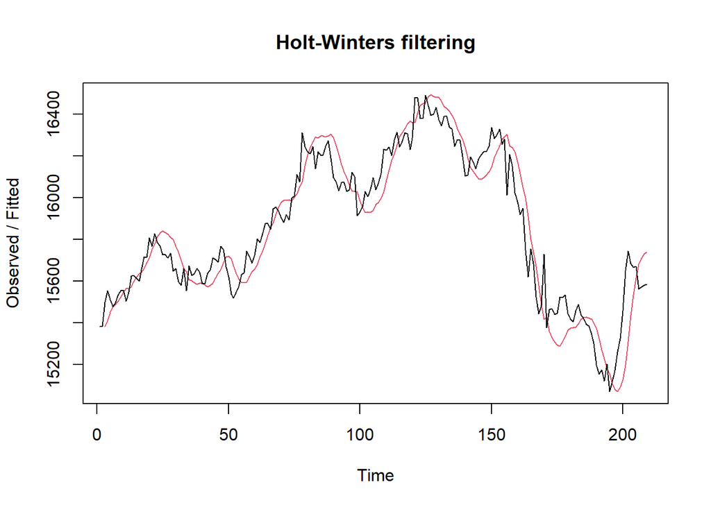

```r
des.1<- HoltWinters(train.ts, gamma = FALSE, beta = 0.2, alpha = 0.2)
plot(des.1)
```

```r
ramalandes1<- forecast(des.1, h=53)
ramalandes1
```

```
##     Point Forecast    Lo 80    Hi 80    Lo 95    Hi 95
## 210       15741.66 15592.10 15891.23 15512.92 15970.40
## 211       15775.68 15621.87 15929.49 15540.45 16010.91
## 212       15809.70 15650.29 15969.11 15565.90 16053.49
## 213       15843.71 15677.28 16010.15 15589.17 16098.26
## 214       15877.73 15702.80 16052.66 15610.20 16145.27
## 215       15911.75 15726.87 16096.63 15629.00 16194.50
## 216       15945.77 15749.53 16142.01 15645.64 16245.89
## 217       15979.79 15770.82 16188.75 15660.21 16299.36
## 218       16013.80 15790.84 16236.77 15672.81 16354.80
## 219       16047.82 15809.64 16286.00 15683.56 16412.08
## 220       16081.84 15827.32 16336.36 15692.58 16471.09
## 221       16115.86 15843.93 16387.78 15699.98 16531.73
## 222       16149.87 15859.55 16440.20 15705.86 16593.88
## 223       16183.89 15874.24 16493.54 15710.32 16657.46
```

[output cut: 39 more lines]

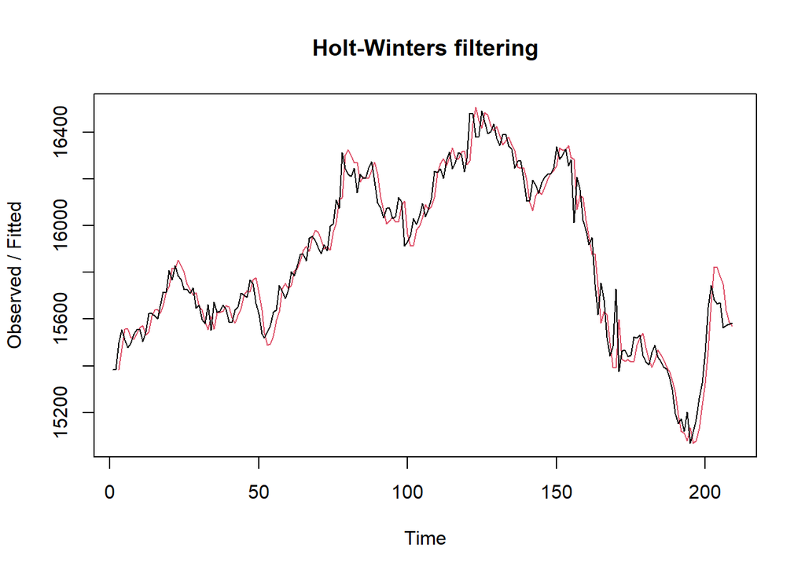

```r
des.2<- HoltWinters(train.ts, gamma = FALSE, beta = 0.3, alpha = 0.6)
plot(des.2)
```

```r
ramalandes2<- forecast(des.2, h=53)
ramalandes2
```

```
##     Point Forecast    Lo 80    Hi 80     Lo 95    Hi 95
## 210       15568.16 15468.82 15667.51 15416.226 15720.10
## 211       15558.09 15432.10 15684.09 15365.398 15750.78
## 212       15548.02 15389.99 15706.04 15306.343 15789.69
## 213       15537.94 15343.53 15732.36 15240.608 15835.28
## 214       15527.87 15293.36 15762.38 15169.215 15886.52
## 215       15517.79 15239.94 15795.65 15092.853 15942.73
## 216       15507.72 15183.59 15831.85 15012.007 16003.43
## 217       15497.64 15124.54 15870.75 14927.034 16068.25
## 218       15487.57 15062.98 15912.16 14838.210 16136.93
## 219       15477.49 14999.04 15955.95 14745.757 16209.23
## 220       15467.42 14932.84 16002.00 14649.856 16284.99
## 221       15457.35 14864.50 16050.20 14550.661 16364.03
## 222       15447.27 14794.08 16100.46 14448.306 16446.24
## 223       15437.20 14721.68 16152.72 14342.907 16531.49
```

[output cut: 39 more lines]

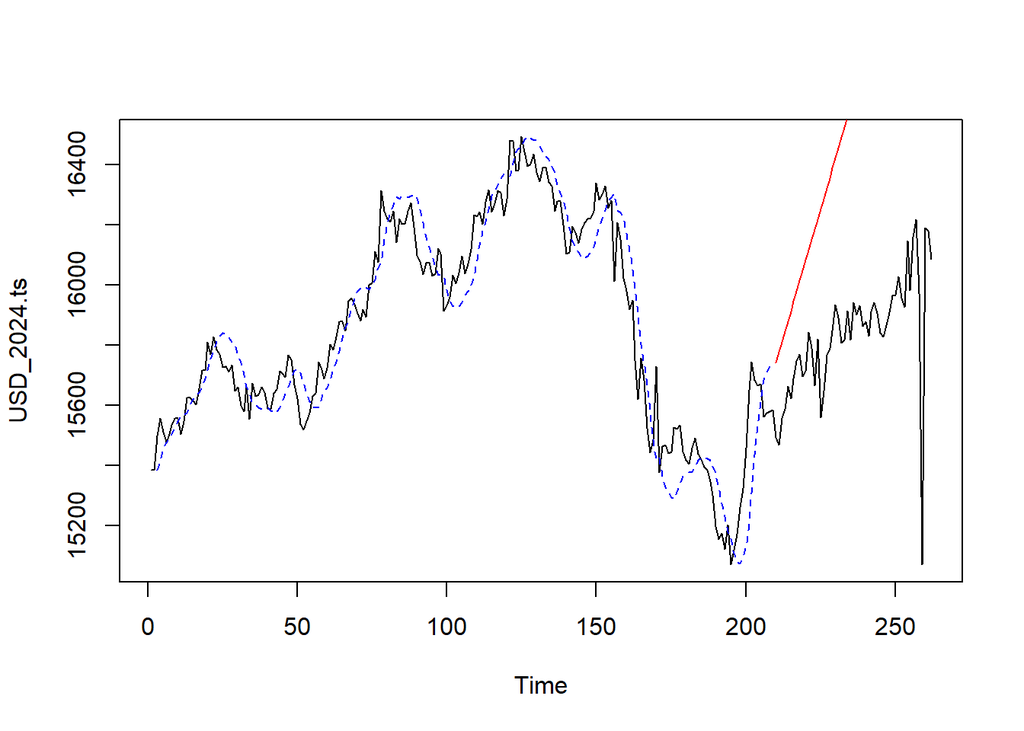

```r
plot(USD_2024.ts)
lines(des.1$fitted[,1], lty=2, col="blue")
lines(ramalandes1$mean, col="red")
```

```r
des.opt<- HoltWinters(train.ts, gamma = FALSE)
des.opt
```

```
## Holt-Winters exponential smoothing with trend and without seasonal component.
##
## Call:
## HoltWinters(x = train.ts, gamma = FALSE)
##
## Smoothing parameters:
##  alpha: 0.8578523
##  beta : 0
##  gamma: FALSE
##
## Coefficients:
##            [,1]
## a  1.558303e+04
## b -9.960938e-02
```

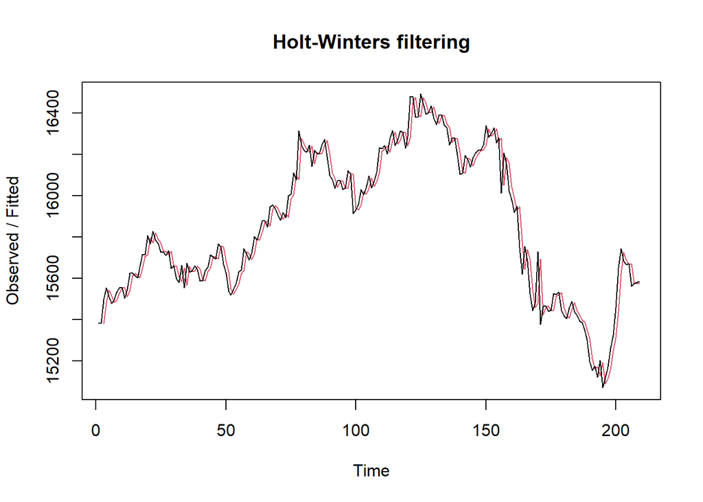

```r
plot(des.opt)
```

```r
ramalandesopt<- forecast(des.opt, h=53)
ramalandesopt
```

```
##     Point Forecast    Lo 80    Hi 80    Lo 95    Hi 95
## 210       15582.93 15488.38 15677.48 15438.33 15727.54
## 211       15582.83 15458.25 15707.41 15392.31 15773.35
## 212       15582.73 15434.08 15731.39 15355.38 15810.08
## 213       15582.63 15413.29 15751.98 15323.64 15841.62
## 214       15582.53 15394.76 15770.30 15295.37 15869.70
## 215       15582.43 15377.89 15786.97 15269.62 15895.25
## 216       15582.33 15362.30 15802.37 15245.82 15918.84
## 217       15582.23 15347.73 15816.74 15223.58 15940.88
## 218       15582.13 15333.99 15830.27 15202.64 15961.63
## 219       15582.03 15320.97 15843.09 15182.78 15981.29
## 220       15581.93 15308.56 15855.30 15163.85 16000.02
## 221       15581.83 15296.68 15866.98 15145.74 16017.93
## 222       15581.74 15285.27 15878.20 15128.34 16035.13
## 223       15581.64 15274.28 15888.99 15111.57 16051.70
```

[output cut: 39 more lines]

Selanjutnya akan dilakukan perhitungan akurasi pada data latih maupun data uji dengan ukuran akurasi SSE, MSE dan MAPE.

```r
ssedes.train1<-des.1$SSE
msedes.train1<-ssedes.train1/length(train.ts)
sisaandes1<-ramalandes1$residuals
head(sisaandes1)
```

```
## Time Series:
## Start = 1
## End = 6
## Frequency = 1
## [1]         NA         NA 115.099609 144.575312  61.372862   2.855988
```

```r
mapedes.train1 <- sum(abs(sisaandes1[3:length(train.ts)]/train.ts[3:length(train.ts)])
                      *100)/length(train.ts)

akurasides.1 <- matrix(c(ssedes.train1,msedes.train1,mapedes.train1))
row.names(akurasides.1)<- c("SSE", "MSE", "MAPE")
colnames(akurasides.1) <- c("Akurasi lamda=0.2 dan gamma=0.2")
akurasides.1
```

```
##      Akurasi lamda=0.2 dan gamma=0.2
## SSE                     2.809237e+06
## MSE                     1.344133e+04
## MAPE                    5.752218e-01
```

```r
ssedes.train2<-des.2$SSE
msedes.train2<-ssedes.train2/length(train.ts)
sisaandes2<-ramalandes2$residuals
head(sisaandes2)
```

```
## Time Series:
## Start = 1
## End = 6
## Frequency = 1
## [1]        NA        NA 115.09961  82.42152 -46.48559 -79.18102
```

```r
mapedes.train2 <- sum(abs(sisaandes2[3:length(train.ts)]/train.ts[3:length(train.ts)])
                      *100)/length(train.ts)

akurasides.2 <- matrix(c(ssedes.train2,msedes.train2,mapedes.train2))
row.names(akurasides.2)<- c("SSE", "MSE", "MAPE")
colnames(akurasides.2) <- c("Akurasi lamda=0.6 dan gamma=0.3")
akurasides.2
```

```
##      Akurasi lamda=0.6 dan gamma=0.3
## SSE                     1.237975e+06
## MSE                     5.923328e+03
## MAPE                    3.672305e-01
```

Hasil akurasi dari data latih didapatkan skenario 2 dengan lamda=0.6 dan gamma=0.3 memiliki hasil yang lebih baik. Namun untuk kedua skenario dapat dikategorikan peramalan sangat baik berdasarkan nilai MAPE-nya.

```r
selisihdes1<-ramalandes1$mean-testing$Close
selisihdes1
```

```
## Time Series:
## Start = 210
## End = 262
## Frequency = 1
##  [1]  248.6618  308.6794  253.6970  257.7146  214.7323  290.2499  257.6679
##  [8]  232.7851  245.8027  352.3203  368.8379  273.8556  359.8732  518.8908
## [15]  399.7082  693.9260  638.7435  554.9613  565.0785  540.7963  488.7143
## [22]  564.7319  683.9497  706.9674  645.0846  775.2018  686.1198  758.9372
## [29]  764.1550  864.6727  884.1903  967.2079  920.2255  924.2431  991.6611
## [36] 1092.4786 1140.4962 1136.3136 1126.3312 1105.3488 1134.9661 1110.5843
## [43] 1215.4017 1278.2191 1093.1371 1291.1547 1147.1723 1122.8902 1403.7076
## [50] 2339.1246 1253.5426 1298.5602 1424.9782
```

```r
SSEtestingdes1<-sum(selisihdes1^2)
MSEtestingdes1<-SSEtestingdes1/length(testing$Close)
MAPEtestingdes1<-sum(abs(selisihdes1/testing$Close)*100)/length(testing$Close)

selisihdes2<-ramalandes2$mean-testing$Close
selisihdes2
```

```
## Time Series:
## Start = 210
## End = 262
## Frequency = 1
##  [1]    75.164828    91.090400    -7.984028   -48.058456  -135.132884
##  [6]  -103.707312  -180.381350  -249.356168  -280.430596  -218.005024
## [11]  -245.579452  -384.653880  -342.728308  -227.802736  -391.077359
## [16]  -140.951592  -240.226215  -368.100448  -402.075267  -470.449499
## [21]  -566.623537  -534.697965  -459.572197  -480.646625  -586.621444
## [26]  -500.596263  -633.770300  -605.044923  -643.919156  -587.493584
## [31]  -612.068012  -573.142440  -664.216868  -704.291296  -680.965333
## [36]  -624.239956  -620.314384  -668.589008  -722.663436  -787.737864
## [41]  -802.212682  -870.686524  -809.961148  -791.235771 -1020.409808
## [46]  -866.484236 -1054.558664 -1122.932897  -886.207520     5.117466
## [51] -1124.556572 -1123.631000 -1041.305037
```

```r
SSEtestingdes2<-sum(selisihdes2^2)
MSEtestingdes2<-SSEtestingdes2/length(testing$Close)
MAPEtestingdes2<-sum(abs(selisihdes2/testing$Close)*100)/length(testing$Close)

selisihdesopt<-ramalandesopt$mean-testing$Close
selisihdesopt
```

```
## Time Series:
## Start = 210
## End = 262
## Frequency = 1
##  [1]   89.930337  115.830727   26.731118   -3.368491  -80.468101  -39.067710
##  [7] -105.766929 -164.766929 -185.866538 -113.466148 -131.065757 -260.165366
## [13] -208.264976  -83.364585 -236.664390   23.436196  -65.863609 -183.763023
## [19] -207.763023 -266.162437 -352.361655 -310.461265 -225.360679 -236.460288
## [25] -332.460288 -236.460288 -359.659507 -320.959312 -349.858726 -283.458335
## [31] -298.057945 -249.157554 -330.257163 -360.356773 -327.055991 -260.355796
## [37] -246.455405 -284.755210 -328.854820 -383.954429 -388.454429 -446.953452
## [43] -376.253257 -347.553062 -566.752280 -402.851890 -580.951499 -639.350913
## [49] -392.650718  508.649087 -611.050132 -600.149741 -507.848960
```

```r
SSEtestingdesopt<-sum(selisihdesopt^2)
MSEtestingdesopt<-SSEtestingdesopt/length(testing$Close)
MAPEtestingdesopt<-sum(abs(selisihdesopt/testing$Close)*100)/length(testing$Close)

akurasitestingdes <-
  matrix(c(SSEtestingdes1,MSEtestingdes1,MAPEtestingdes1,SSEtestingdes2,MSEtestingdes2,
           MAPEtestingdes2,SSEtestingdesopt,MSEtestingdesopt,MAPEtestingdesopt),
         nrow=3,ncol=3)
row.names(akurasitestingdes)<- c("SSE", "MSE", "MAPE")
colnames(akurasitestingdes) <- c("des ske1","des ske2","des opt")
akurasitestingdes
```

```
##          des ske1     des ske2      des opt
## SSE  4.270217e+07 2.027829e+07 5.597813e+06
## MSE  8.057013e+05 3.826093e+05 1.056191e+05
## MAPE 4.985768e+00 3.359069e+00 1.783235e+00
```

## Perbandingan SES dan DES

```r
MSEfull <-
  matrix(c(MSEtesting1,MSEtesting2,MSEtestingopt,MSEtestingdes1,MSEtestingdes2,
           MSEtestingdesopt),nrow=3,ncol=2)
row.names(MSEfull)<- c("ske 1", "ske 2", "ske opt")
colnames(MSEfull) <- c("ses","des")
MSEfull
```

```
##              ses      des
## ske 1   113807.1 805701.3
## ske 2   104192.3 382609.3
## ske opt 103861.6 105619.1
```

Kedua metode dapat dibandingkan dengan menggunakan ukuran akurasi yang sama. Contoh di atas adalah perbandingan kedua metode dengan ukuran akurasi MSE. Hasilnya didapatkan metode SES lebih baik dibandingkan metode DES dilihat dari MSE yang lebih kecil nilainya.